# PML course Project

Klajdi Qirko

December 24, 2015

# **Background Information**

Using devices such as Jawbone Up, Nike FuelBand, and Fitbit it is now possible to collect a large amount of data about personal activity relatively inexpensively. These type of devices are part of the quantified self movement ??? a group of enthusiasts who take measurements about themselves regularly to improve their health, to find patterns in their behavior, or because they are tech geeks. One thing that people regularly do is quantify how much of a particular activity they do, but they rarely quantify how well they do it. In this project, your goal will be to use data from accelerometers on the belt, forearm, arm, and dumbbell of 6 participants. They were asked to perform barbell lifts correctly and incorrectly in 5 different ways. More information is available from the website here: http://groupware.les.inf.puc-rio.br/har (see the section on the Weight Lifting Exercise Dataset).

# **Data Processing**

### 1.**Getting and Loading the Data**

```r
# load the required packages
library(caret); library(rattle); library(rpart); library(rpart.plot)
library(randomForest);
```

```r
# Getting the data (on the memory)
# training data url
trainUrl <- "http://d396qusza40orc.cloudfront.net/predmachlearn/pml-training.csv"
#testing data url
testUrl <- "http://d396qusza40orc.cloudfront.net/predmachlearn/pml-testing.csv"
# loading the data
training <- read.csv(url(trainUrl), na.strings = c("NA","#DIV/0!",""))
testing <- read.csv(url(testUrl), na.strings=c("NA","#DIV/0!",""))
```

### 2.**Split the training set**

```r
inTR <- createDataPartition(y = training$classe, p = 0.6, list = FALSE)
train <- training[inTR,]
probe <- training[-inTR,]
# splitting the probe set into validation set and test set
intst <- createDataPartition(y = probe$classe, p = 0.5, list = FALSE)
validation <- probe[-intst,]
TRtest <- probe[intst,]
```

### 3.**Exploratory Data Analysis**

We run a summary on the data to have an overall look! I am holding the output since it is very long and displaying it at the end of the data.

```r
summary(training)
```

```
##        X            user_name    raw_timestamp_part_1 raw_timestamp_part_2
##  Min.   :    1   adelmo  :3892   Min.   :1.322e+09    Min.   :   294
##  1st Qu.: 4906   carlitos:3112   1st Qu.:1.323e+09    1st Qu.:252912
##  Median : 9812   charles :3536   Median :1.323e+09    Median :496380
##  Mean   : 9812   eurico  :3070   Mean   :1.323e+09    Mean   :500656
##  3rd Qu.:14717   jeremy  :3402   3rd Qu.:1.323e+09    3rd Qu.:751891
##  Max.   :19622   pedro   :2610   Max.   :1.323e+09    Max.   :998801
##
##           cvtd_timestamp  new_window    num_window      roll_belt
##  28/11/2011 14:14: 1498   no :19216   Min.   :  1.0   Min.   :-28.90
##  05/12/2011 11:24: 1497   yes:  406   1st Qu.:222.0   1st Qu.:  1.10
##  30/11/2011 17:11: 1440               Median :424.0   Median :113.00
##  05/12/2011 11:25: 1425               Mean   :430.6   Mean   : 64.41
##  02/12/2011 14:57: 1380               3rd Qu.:644.0   3rd Qu.:123.00
##  02/12/2011 13:34: 1375               Max.   :864.0   Max.   :162.00
##  (Other)         :11007
##    pitch_belt          yaw_belt       total_accel_belt kurtosis_roll_belt
##  Min.   :-55.8000   Min.   :-180.00   Min.   : 0.00    Min.   :-2.121
##  1st Qu.:  1.7600   1st Qu.: -88.30   1st Qu.: 3.00    1st Qu.:-1.329
##  Median :  5.2800   Median : -13.00   Median :17.00    Median :-0.899
##  Mean   :  0.3053   Mean   : -11.21   Mean   :11.31    Mean   :-0.220
##  3rd Qu.: 14.9000   3rd Qu.:  12.90   3rd Qu.:18.00    3rd Qu.:-0.219
##  Max.   : 60.3000   Max.   : 179.00   Max.   :29.00    Max.   :33.000
##                                                        NA's   :19226
##  kurtosis_picth_belt kurtosis_yaw_belt skewness_roll_belt
##  Min.   :-2.190      Mode:logical      Min.   :-5.745
##  1st Qu.:-1.107      NA's:19622        1st Qu.:-0.444
##  Median :-0.151                        Median : 0.000
##  Mean   : 4.334                        Mean   :-0.026
##  3rd Qu.: 3.178                        3rd Qu.: 0.417
##  Max.   :58.000                        Max.   : 3.595
##  NA's   :19248                         NA's   :19225
##  skewness_roll_belt.1 skewness_yaw_belt max_roll_belt     max_picth_belt
##  Min.   :-7.616       Mode:logical      Min.   :-94.300   Min.   : 3.00
##  1st Qu.:-1.114       NA's:19622        1st Qu.:-88.000   1st Qu.: 5.00
##  Median :-0.068                         Median : -5.100   Median :18.00
##  Mean   :-0.296                         Mean   : -6.667   Mean   :12.92
##  3rd Qu.: 0.661                         3rd Qu.: 18.500   3rd Qu.:19.00
##  Max.   : 7.348                         Max.   :180.000   Max.   :30.00
##  NA's   :19248                          NA's   :19216     NA's   :19216
```

[output cut: 313 more lines]

```
##  Min.   :-446.00   Min.   :-1280.0   Min.   :-896.0   Min.   :-973.0
##  1st Qu.:-182.00   1st Qu.: -616.0   1st Qu.:   2.0   1st Qu.: 191.0
##  Median : -39.00   Median : -378.0   Median : 591.0   Median : 511.0
##  Mean   : -55.29   Mean   : -312.6   Mean   : 380.1   Mean   : 393.6
##  3rd Qu.:  26.00   3rd Qu.:  -73.0   3rd Qu.: 737.0   3rd Qu.: 653.0
##  Max.   : 291.00   Max.   :  672.0   Max.   :1480.0   Max.   :1090.0
##
##  classe
##  A:5580
##  B:3797
##  C:3422
##  D:3216
##  E:3607
##
##
```

From the summary we see that many columns have many missing values and they consist only of the statistics for data that are in other columns(average, standard dev, curtosis). Since a large number of the values is NA we will have to remove this columns when we build the predictive model. We also notice that the first 7 columns will not help withe prediction at all. Before we remove all this columns we subset the data by taking the data values that correspond to only one of the volunteers which i chose to be pedro. We do this to be able to do some exploration that will help us detect which of the variables have bigger contribution in describing the variation of the data and therefore will help us in our classification algorithm.

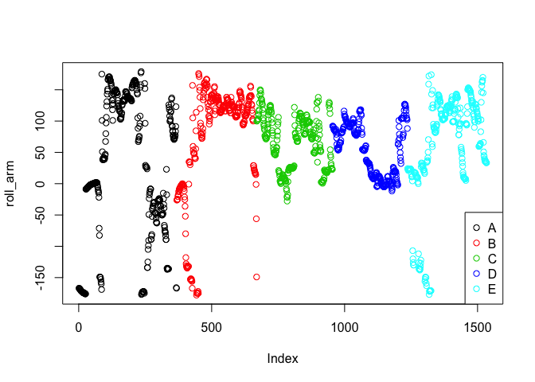

```r
trainpedro <- subset(train, user_name == "pedro")
# looking at a plot of one of the variables that might be very important.
with(trainpedro, plot(roll_arm, col = classe))
legend("bottomright", legend = unique(trainpedro$classe), col = unique(trainpedro$classe), pch = 1)
```

We see that the roll_arm variable explains some variation in the classes A,B and E. Thus, this is a good indication that it should be included as a predictor. We need a deeper analysis now on determining the other variables. First thing we do is get rid of the variables that were not helpful as explained above. This is what the following code accomplishes.

```r
# calculating the total number of NA per column.
totna = apply(trainpedro, 2, function(col) sum(is.na(col)))
# vector with the first 7 column numbers that we will use to take them out of our train set.
out = c(1:7)
# Since the columns that we will use have no NAs we can use as subsetting rule the zero values of
# the totna vector. We make 1 the entries for the first 7 columns since we will not keep them either.
totna[out] = 1
trainpedro <- trainpedro[, totna == 0]

# Now we apply the same subsetting for all the other data sets.
train <- train[, totna == 0]
validation <- validation[, totna == 0]
TRtest <- TRtest[, totna == 0]
testing <- testing[, totna == 0]
# checking that we have the same number of variables for all sets
dim(train); dim(validation); dim(TRtest); dim(testing)
```

```
## [1] 11776    53
```

```
## [1] 3923   53
```

```
## [1] 3923   53
```

```
## [1] 20 53
```

Now we can run a svd decomposition on the data and find out the max. contributor from the first 4 right singular vectors and their corresponding variable names.

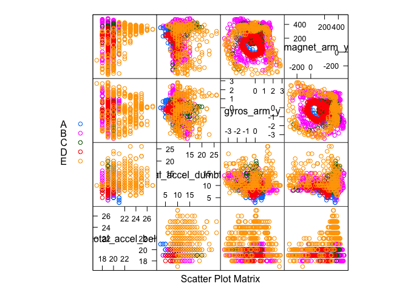

```r
svd1 <- svd(scale(trainpedro[,-53]))
maxContrib <- apply(svd1$v[,1:4], 2,  which.max)
# plotting the biggest contributor features
featurePlot(x = trainpedro[,names(trainpedro)[maxContrib]], y = trainpedro$classe, plot = "pairs", auto.key = list(space = "left") )
```

From the plot we can clearly see that even though these features explain some of the variability in the data we still do not capture the separation of the groups.

### 4.**Feature Selection**

The next approach is to do a K-means clustering and find out what features are the most influential when determining the centers of the 5 classes.

```r
kclust <- kmeans(trainpedro[,-53], centers = 5, nstart = 100,iter.max = 100)
# checking if the clustering is separating the groups
table(kclust$cluster, trainpedro$classe)
```

```
##
##       A   B   C   D   E
##   1  90  40 141  98  39
##   2 194  92 113   7 119
##   3  30  79   5  81  46
##   4   0  51  26  29  44
##   5  54  39   0  67  50
```

```r
Acenters <- abs(kclust$center[1,])
A <- colnames(trainpedro[order(Acenters, decreasing = TRUE)[1:20]])
Bcenters <- abs(kclust$center[2,])
B <- colnames(trainpedro[order(Bcenters, decreasing = TRUE)[1:20]])
Ccenters <- abs(kclust$center[3,])
C <- colnames(trainpedro[order(Ccenters, decreasing = TRUE)[1:20]])
Dcenters <- abs(kclust$center[4,])
D <- colnames(trainpedro[order(Dcenters, decreasing = TRUE)[1:20]])
Ecenters <- abs(kclust$center[5,])
E <- colnames(trainpedro[order(Ecenters, decreasing = TRUE)[1:20]])
```

```r
ABCDE <- c(A, "accel_arm_x", "accel_forearm_x", "magnet_belt_z","total_accel_belt", "total_accel_dumbbell", "classe" )
# checking the number of features
length(ABCDE)
```

```
## [1] 26
```

### **Final subsetting of the data**

```r
train <- train[,ABCDE]
validation <- validation[,ABCDE]
TRtest <- TRtest[,ABCDE]
testing <- testing[,c(ABCDE[-26],"problem_id")]
```

```r
# fitcontrol parameters are going to be used for all three methods to make it possible for us to fairly compare them.
set.seed(2212)
#fitcontrol <- trainControl(method = "repeatedcv", number = 10, repeats = 5,classProbs = TRUE)
fitcontrol <- trainControl(method = "repeatedcv", number = 5, repeats = 1,classProbs = TRUE)
rf <- randomForest(classe~., data = train, trcontrol = fitcontrol, ntree = 300, importance= TRUE, proximity = TRUE)
set.seed(2212)
#svm <- train(classe~., data = train, trControl = fitcontrol, method = "svmRadial", verbose = #FALSE,
#              preProc = c("center", "scale"),tunelength = 8 )
treefit <- train(classe ~., data = train, method ="rpart")
set.seed(2212)
gbm <- train(classe~., data = train, trControl = fitcontrol, method = "gbm", verbose = FALSE,
              preProc = c("center", "scale"))
```

Checking the models and which one has the best accuracy:

**Prediction wiht Decision Trees**

```r
cMtree <- confusionMatrix(validation$classe, predict(treefit, validation))
cMtree
```

```
## Confusion Matrix and Statistics
##
##           Reference
## Prediction    A    B    C    D    E
##          A 1005    0  110    0    1
##          B  521    0  238    0    0
##          C  333    0  351    0    0
##          D  416    0  227    0    0
##          E  162    0  235    0  324
##
## Overall Statistics
##
##                Accuracy : 0.4282
##                  95% CI : (0.4127, 0.4439)
##     No Information Rate : 0.6212
##     P-Value [Acc > NIR] : 1
##
##                   Kappa : 0.2442
##  Mcnemar's Test P-Value : NA
##
## Statistics by Class:
##
##                      Class: A Class: B Class: C Class: D Class: E
## Sensitivity            0.4124       NA  0.30233       NA  0.99692
## Specificity            0.9253   0.8065  0.87944   0.8361  0.88966
## Pos Pred Value         0.9005       NA  0.51316       NA  0.44938
## Neg Pred Value         0.4898       NA  0.74992       NA  0.99969
## Prevalence             0.6212   0.0000  0.29595   0.0000  0.08284
## Detection Rate         0.2562   0.0000  0.08947   0.0000  0.08259
## Detection Prevalence   0.2845   0.1935  0.17436   0.1639  0.18379
## Balanced Accuracy      0.6688       NA  0.59088       NA  0.94329
```

[figure not shown]

```r
fancyRpartPlot(treefit$finalModel)
```

**Prediction with Random Forest**

```r
cMrf <- confusionMatrix(validation$classe, predict(rf, validation))
cMrf
```

```
## Confusion Matrix and Statistics
##
##           Reference
## Prediction    A    B    C    D    E
##          A 1106    0    4    6    0
##          B    8  747    3    1    0
##          C    1    3  677    3    0
##          D    2    0   11  630    0
##          E    0    2    5    4  710
##
## Overall Statistics
##
##                Accuracy : 0.9865
##                  95% CI : (0.9824, 0.9899)
##     No Information Rate : 0.2847
##     P-Value [Acc > NIR] : < 2.2e-16
##
##                   Kappa : 0.9829
##  Mcnemar's Test P-Value : NA
##
## Statistics by Class:
##
##                      Class: A Class: B Class: C Class: D Class: E
## Sensitivity            0.9902   0.9934   0.9671   0.9783   1.0000
## Specificity            0.9964   0.9962   0.9978   0.9960   0.9966
## Pos Pred Value         0.9910   0.9842   0.9898   0.9798   0.9847
## Neg Pred Value         0.9961   0.9984   0.9929   0.9957   1.0000
## Prevalence             0.2847   0.1917   0.1784   0.1642   0.1810
## Detection Rate         0.2819   0.1904   0.1726   0.1606   0.1810
## Detection Prevalence   0.2845   0.1935   0.1744   0.1639   0.1838
## Balanced Accuracy      0.9933   0.9948   0.9825   0.9871   0.9983
```

We see that we get a very high accuracy level using the Random Forest algorithm but we have to be careful that we are not overfitting. To check this we need to check the out of sample error for all three methods and choose the one with the lowest out of sample error. This is the reason i have split the training set into three subsets, so that we can apply the 2 best methods to the TRtest set and compare the Out of Sample Error. Now let us check the last prediction model.

**Prediction with the Gradient Boosting Method**

```r
cMgbm <- confusionMatrix(validation$classe, predict(gbm, validation))
cMgbm
```

```
## Confusion Matrix and Statistics
##
##           Reference
## Prediction    A    B    C    D    E
##          A 1090    2   11   12    1
##          B   41  640   53   21    4
##          C    5   48  616   15    0
##          D   13   16   33  581    0
##          E    4   11   17   10  679
##
## Overall Statistics
##
##                Accuracy : 0.9192
##                  95% CI : (0.9102, 0.9275)
##     No Information Rate : 0.2939
##     P-Value [Acc > NIR] : < 2.2e-16
##
##                   Kappa : 0.8977
##  Mcnemar's Test P-Value : 1.618e-12
##
## Statistics by Class:
##
##                      Class: A Class: B Class: C Class: D Class: E
## Sensitivity            0.9454   0.8926   0.8438   0.9092   0.9927
## Specificity            0.9906   0.9629   0.9787   0.9811   0.9870
## Pos Pred Value         0.9767   0.8432   0.9006   0.9036   0.9417
## Neg Pred Value         0.9776   0.9757   0.9648   0.9823   0.9984
## Prevalence             0.2939   0.1828   0.1861   0.1629   0.1744
## Detection Rate         0.2778   0.1631   0.1570   0.1481   0.1731
## Detection Prevalence   0.2845   0.1935   0.1744   0.1639   0.1838
## Balanced Accuracy      0.9680   0.9277   0.9113   0.9452   0.9899
```

The expected OSE for the three methods are: Tree:0.5717563, rf:0.0135101, gbm: 0.0808055. From this preliminary OSE The Random Forest prediction model has the lowest Out Of Sample Error. The final estimates for the OSE will be computed after we apply these 2 models on the TRtest.

```r
cMfrf <- confusionMatrix(TRtest$classe, predict(rf, TRtest))
cMfrf
```

```
## Confusion Matrix and Statistics
##
##           Reference
## Prediction    A    B    C    D    E
##          A 1111    3    2    0    0
##          B   12  739    6    2    0
##          C    0    6  674    4    0
##          D    0    0   15  626    2
##          E    0    0    3    6  712
##
## Overall Statistics
##
##                Accuracy : 0.9845
##                  95% CI : (0.9801, 0.9881)
##     No Information Rate : 0.2863
##     P-Value [Acc > NIR] : < 2.2e-16
##
##                   Kappa : 0.9803
##  Mcnemar's Test P-Value : NA
##
## Statistics by Class:
##
##                      Class: A Class: B Class: C Class: D Class: E
## Sensitivity            0.9893   0.9880   0.9629   0.9812   0.9972
## Specificity            0.9982   0.9937   0.9969   0.9948   0.9972
## Pos Pred Value         0.9955   0.9736   0.9854   0.9736   0.9875
## Neg Pred Value         0.9957   0.9972   0.9920   0.9963   0.9994
## Prevalence             0.2863   0.1907   0.1784   0.1626   0.1820
## Detection Rate         0.2832   0.1884   0.1718   0.1596   0.1815
## Detection Prevalence   0.2845   0.1935   0.1744   0.1639   0.1838
## Balanced Accuracy      0.9938   0.9908   0.9799   0.9880   0.9972
```

```r
cMfgbm <- confusionMatrix(TRtest$classe, predict(gbm, TRtest))
cMfgbm
```

```
## Confusion Matrix and Statistics
##
##           Reference
## Prediction    A    B    C    D    E
##          A 1084    8   10   13    1
##          B   47  643   47   17    5
##          C    4   44  622   13    1
##          D   12   14   32  583    2
##          E    6   14   13   14  674
##
## Overall Statistics
##
##                Accuracy : 0.9192
##                  95% CI : (0.9102, 0.9275)
##     No Information Rate : 0.2939
##     P-Value [Acc > NIR] : < 2.2e-16
##
##                   Kappa : 0.8977
##  Mcnemar's Test P-Value : 2.852e-10
##
## Statistics by Class:
##
##                      Class: A Class: B Class: C Class: D Class: E
## Sensitivity            0.9402   0.8893   0.8591   0.9109   0.9868
## Specificity            0.9884   0.9637   0.9806   0.9817   0.9855
## Pos Pred Value         0.9713   0.8472   0.9094   0.9067   0.9348
## Neg Pred Value         0.9754   0.9747   0.9685   0.9826   0.9972
## Prevalence             0.2939   0.1843   0.1846   0.1631   0.1741
## Detection Rate         0.2763   0.1639   0.1586   0.1486   0.1718
## Detection Prevalence   0.2845   0.1935   0.1744   0.1639   0.1838
## Balanced Accuracy      0.9643   0.9265   0.9199   0.9463   0.9862
```

Out of Sample Error Estimates: rf:0.0155493, gbm: 0.0808055. We can see that the most accurate model is the Random Forest model. We are going to use it to predict the class for the test set.

# **Test Predictions**

```r
predictrf <- predict(rf, testing)
predictrf
```

```
##  1  2  3  4  5  6  7  8  9 10 11 12 13 14 15 16 17 18 19 20
##  B  A  B  A  A  E  D  B  A  A  B  C  B  A  E  E  A  B  B  B
## Levels: A B C D E
```

```r
predictgbm <- predict(gbm, testing)
```

Finally we check if the predictions from the two algorithms are the same.

```r
table(predictrf,predictgbm)
```

```
##          predictgbm
## predictrf A B C D E
##         A 7 0 0 0 0
##         B 0 6 2 0 0
##         C 0 0 1 0 0
##         D 0 0 0 1 0
##         E 0 0 0 0 3
```